# by Darrell Wolfe, & R_Analysis CodeBase

## Annotating Viz

We can add:

- Title - Bold top of visualization
- Subtitle - Smaller below title
- Caption - below graph
- Annotation - Label inside graph

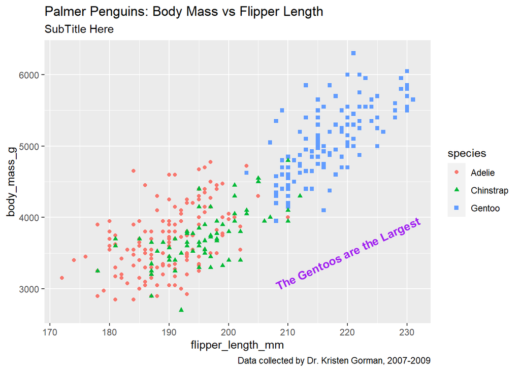

```r
library(ggplot2)
library(palmerpenguins)
ggplot(data = penguins) +
  geom_point(mapping = aes(x = flipper_length_mm, y = body_mass_g, color=species, shape = species)) +
labs(title = "Palmer Penguins: Body Mass vs Flipper Length", subtitle = "SubTitle Here", caption = "Data collected by Dr. Kristen Gorman, 2007-2009") +
annotate("text",x=220,y=3500,label="The Gentoos are the Largest", color = "purple",fontface = "bold", size=4.0, angle=25)
```

## Assigning a variable to an entire plotted graph

Type anything you want (letters before numbers) followed by the assignment (<-) and place the ggplot after this. Than you can add things to the variable.

```r
library(ggplot2)
library(palmerpenguins)


p <- ggplot(data = penguins) +
  geom_point(mapping = aes(x = flipper_length_mm, y = body_mass_g, color=species, shape = species)) +
labs(title = "Palmer Penguins: Body Mass vs Flipper Length", subtitle = "SubTitle Here", caption = "Data collected by Dr. Kristen Gorman, 2007-2009")


psaved <- p + annotate("text",x=220,y=3500,label="The Gentoos are the Largest", color = "purple",fontface = "bold", size=4.0, angle=25)
```

## Saving Work

In the Plots tab in RStudio, you can export the images (png, jpg, etc.) to a specified location.

Alternatively, you can use `ggsave("Title.png")` and it will automatically save this to your RStudio Files.

```r
library(ggplot2)
library(palmerpenguins)


p <- ggplot(data = penguins) +
  geom_point(mapping = aes(x = flipper_length_mm, y = body_mass_g, color=species, shape = species)) +
labs(title = "Palmer Penguins: Body Mass vs Flipper Length", subtitle = "SubTitle Here", caption = "Data collected by Dr. Kristen Gorman, 2007-2009")


psaved <- p + annotate("text",x=220,y=3500,label="The Gentoos are the Largest", color = "purple",fontface = "bold", size=4.0, angle=25)

ggsave("Three Penguins.png")
```

# Other ggplot2 options

1. Facests
2. Smooth
3. Alpha

GPT-4: “Certainly! In the `ggplot2` package in R, visualization is built up through layers, allowing users to iteratively add elements to their plots. Let’s go through each of the items you listed:

1. **Facets**:
   - Facets are a way to create multiple small plots (sub-plots) that share the same x and y axes, arranged in a grid. This is extremely useful for visualizing data across different subgroups or categories.
   - Two primary functions are used to create facets:
     - `facet_wrap(~variable, nrow = , ncol = )`: It wraps a 1D sequence of panels into a 2D grid.
     - `facet_grid(rows = ~variable1, cols = ~variable2)`: It creates a 2D grid of panels. You can facet by a variable on rows and/or columns.
   - Example: `R library(ggplot2) ggplot(mpg, aes(x=displ, y=hwy)) + geom_point() + facet_wrap(~class, nrow=2)`
2. **Smooth**:
   - The `geom_smooth()` function adds a smoothed line (typically a regression line) to a scatter plot, helping to show trends or patterns in the data. By default, if the dataset is large, it uses a method called ‘loess’ (locally estimated scatterplot smoothing). For smaller datasets or for categorical x-axis, it will compute a linear model.
   - You can specify the method you want using the `method` argument.
   - Example: `R ggplot(mpg, aes(x=displ, y=hwy)) + geom_point() + geom_smooth()`
3. **Alpha**:
   - Alpha refers to the transparency level of a geom (graphic element). It takes values between 0 (completely transparent) and 1 (completely opaque).
   - Adjusting the alpha level can be particularly useful when dealing with overlapping points in scatter plots, as it helps to visualize the density of points.
   - The `alpha` argument can be set in most geoms to adjust transparency.
   - Example: `R ggplot(mpg, aes(x=displ, y=hwy)) + geom_point(alpha=0.5)` In this example, points in the scatter plot will be semi-transparent.

These are just basic overviews of each concept. The flexibility and power of `ggplot2` allow for much deeper customization and control over visualizations.”

```r
library(ggplot2)
library(palmerpenguins)


p <- ggplot(data = penguins) +
  geom_point(mapping = aes(x = flipper_length_mm, y = body_mass_g, color=species, shape = species, alpha=0.5)) +
labs(title = "Palmer Penguins: Body Mass vs Flipper Length", subtitle = "SubTitle Here", caption = "Data collected by Dr. Kristen Gorman, 2007-2009")


psaved <- p + annotate("text",x=220,y=3500,label="The Gentoos are the Largest", color = "purple",fontface = "bold", size=4.0, angle=25) +
    facet_wrap(~species, nrow=2)

# ggsave("Three Penguins.png")
```

# Future Sections Under Construction …